### Loading and preprocessing the data

```r
setwd("C:/Rob/courses etc/Data Science/REPRODUCIBLE_RESEARCH/Assignment1")
myData <- read.csv("activity.csv")
```

### What is the mean total number of steps taken per day?

Code for calculating the total number of steps per day:

```r
dailySteps <- aggregate(steps~date,myData,sum)
meanDailySteps <- mean(dailySteps$steps)
medianDailySteps <- median(dailySteps$steps)
```

Histogram of total daily steps:

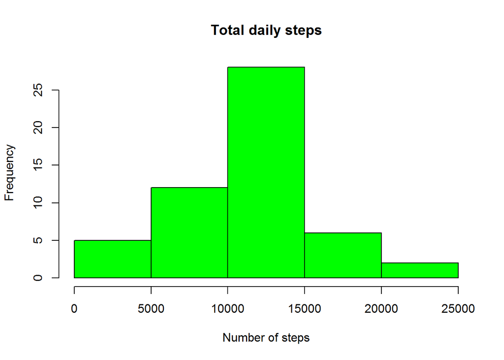

```r
hist(dailySteps$steps,main ="Total daily steps",xlab="Number of steps",col="green")
```

Mean total number of steps taken per day:

```r
meanDailySteps
```

```
## [1] 10766.19
```

Median total number of steps taken per day:

```r
medianDailySteps
```

```
## [1] 10765
```

### What is the average daily activity pattern?

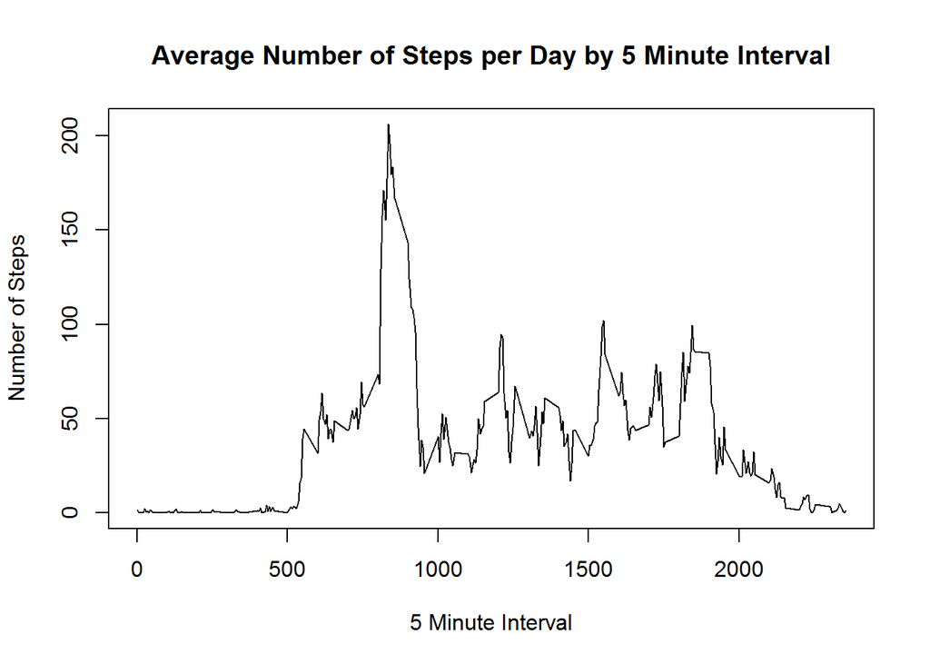

```r
intervalSteps <- aggregate(steps~interval,myData,mean)
plot(intervalSteps$interval,intervalSteps$steps, type="l", xlab="5 Minute Interval", ylab="Number of Steps",main="Average Number of Steps per Day by 5 Minute Interval")
```

```r
maxInterval <- intervalSteps[which.max(intervalSteps$steps),1]
```

The 5-minute interval that contains on average the maximum number of steps is 835

### Imputing missing values

1. Calculate and report the total number of missing values in the dataset (i.e. the total number of rows with NAs)

```r
sum(is.na(myData$steps))
```

```
## [1] 2304
```

2. Devise a strategy for filling in all of the missing values in the dataset. The strategy does not need to be sophisticated. For example, you could use the mean/median for that day, or the mean for that 5-minute interval, etc.

The strategy used is filling in missing values for 5 minute intervals with the mean over all days of the same 5 minute interval.

3. Create a new dataset that is equal to the original dataset but with the missing data filled in.

New dataset is impData

```r
impData <- transform(myData, steps = ifelse(is.na(myData$steps), intervalSteps$steps[match(myData$interval, intervalSteps$interval)], myData$steps))
dailyStepsInt <- aggregate(steps~date,impData,sum)
```

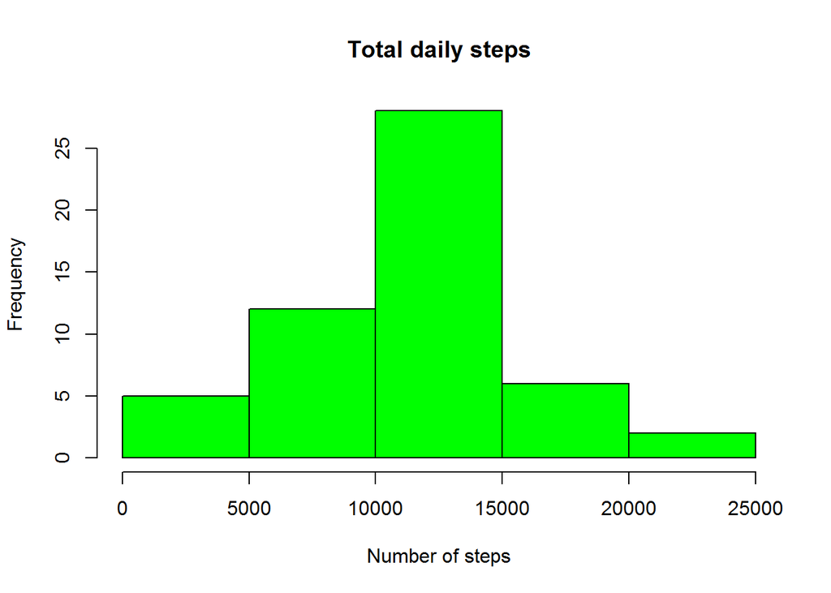

```r
meanDailyStepsImp <- mean(dailyStepsInt$steps)
medianDailyStepsImp <- median(dailyStepsInt$steps)
hist(dailySteps$steps,main ="Total daily steps",xlab="Number of steps",col="green")
```

mean number of steps per day:

```r
meanDailyStepsImp
```

```
## [1] 10766.19
```

median number of steps per day

```r
medianDailyStepsImp
```

```
## [1] 10766.19
```

### Are there differences in activity patterns between weekdays and weekends?

1. Create a new factor variable in the dataset with two levels - “weekday” and “weekend” indicating whether a given date is a weekday or weekend day.

```r
impData$dayType <- ifelse((weekdays(as.Date(impData$date)) == "Saturday") |(weekdays(as.Date(impData$date)) == "Sunday") ,"weekend", "weekday")
```

2. Make a panel plot containing a time series plot (i.e. type = “l”) of the 5-minute interval (x-axis) and the average number of steps taken, averaged across all weekday days or weekend days (y-axis). See the README file in the GitHub repository to see an example of what this plot should look like using simulated data.

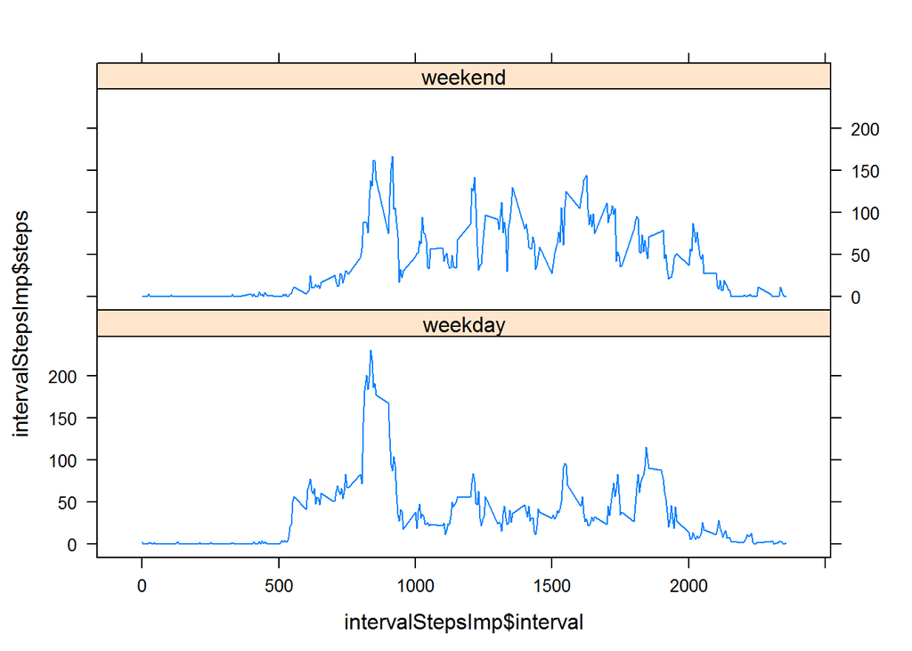

```r
intervalStepsImp <- aggregate(steps~interval + dayType,impData,mean)
library(lattice)
xyplot(intervalStepsImp$steps ~ intervalStepsImp$interval | intervalStepsImp$dayType ,layout=c(1,2),type="l")
```